# Trabalho Final

Eduardo de Castro Luiz

02/11/2021

### Objetivos

Primeiramente iremos ver a porcentagem de homens que abusam ou não de álcool, após esse primeiro momento iremos comparar as estatísticas descritivas de idade e escolaridade para ver se possui alguma correlação entre os homens que abusam ou não de álcool.

### Resultados

Porcentagem de homens que abusa e não abusa de Álcool.

```r
df$abuse
```

[output not shown]

[output cut: 251 more lines]

```r
df %>%
  summarise(Porcentagem_Abuso = mean(abuse)*100,
            Porcentagem_NaoAbusa = 100 - Porcentagem_Abuso)
```

```
## # A tibble: 1 x 2
##   Porcentagem_Abuso Porcentagem_NaoAbusa
##               <dbl>                <dbl>
## 1              9.92                 90.1
```

Estatísticas descritivas por anos de educação da amostra total, sem distinção entre os grupos.

```r
df$educ
```

[output not shown]

[output cut: 395 more lines]

```r
df %>%
  summarise(abuse = "Geral",
            Mínimo = min(educ),
            Média = mean(educ),
            Mediana = median(educ),
            Desvio = sd(educ),
            Máximo = max(educ),
            Amostra = n())
```

```
## # A tibble: 1 x 7
##   abuse Mínimo Média Mediana Desvio Máximo Amostra
##   <chr>  <dbl> <dbl>   <dbl>  <dbl>  <dbl>   <int>
## 1 Geral      0  13.3      13   2.90     19    9822
```

Estatísticas descritivas por anos de educação da amostra total, com distinção entre os grupos que abusa ou não do álcool.

```r
df %>%
  group_by(abuse) %>%
  summarise(Mínimo = min(educ),
            Média = mean(educ),
            Mediana = median(educ),
            Desvio = sd(educ),
            Máximo = max(educ),
            Amostra = n())
```

```
## # A tibble: 2 x 7
##   abuse Mínimo Média Mediana Desvio Máximo Amostra
##   <dbl>  <dbl> <dbl>   <dbl>  <dbl>  <dbl>   <int>
## 1     0      0  13.3      13   2.91     19    8848
## 2     1      0  13.0      12   2.78     19     974
```

Estatísticas descritivas por idade da amostra total, sem distinção entre os grupos.

```r
df$age
```

[output not shown]

[output cut: 395 more lines]

```r
df %>%
  summarise(abuse = "Geral",
            Mínimo = min(age),
            Média = mean(age),
            Mediana = median(age),
            Desvio = sd(age),
            Máximo = max(age),
            Amostra = n())
```

```
## # A tibble: 1 x 7
##   abuse Mínimo Média Mediana Desvio Máximo Amostra
##   <chr>  <dbl> <dbl>   <dbl>  <dbl>  <dbl>   <int>
## 1 Geral     25  39.2      38   9.64     59    9822
```

Estatísticas descritivas por idade da amostra total, com distinção entre os grupos que abusa ou não do álcool.

```r
df %>%
  group_by(abuse) %>%
  summarise(Mínimo = min(age),
            Média = mean(age),
            Mediana = median(age),
            Desvio = sd(age),
            Máximo = max(age),
            Amostra = n())
```

```
## # A tibble: 2 x 7
##   abuse Mínimo Média Mediana Desvio Máximo Amostra
##   <dbl>  <dbl> <dbl>   <dbl>  <dbl>  <dbl>   <int>
## 1     0     25  39.1      38   9.63     59    8848
## 2     1     25  39.4      38   9.71     59     974
```

Comparação entre as variaveis abuse, educ e age.

```r
df %>%
  select(abuse, age, educ) %>%
  cor()
```

```
##              abuse          age       educ
## abuse  1.000000000  0.008336228 -0.0350867
## age    0.008336228  1.000000000 -0.1003623
## educ  -0.035086701 -0.100362312  1.0000000
```

### Gráficos

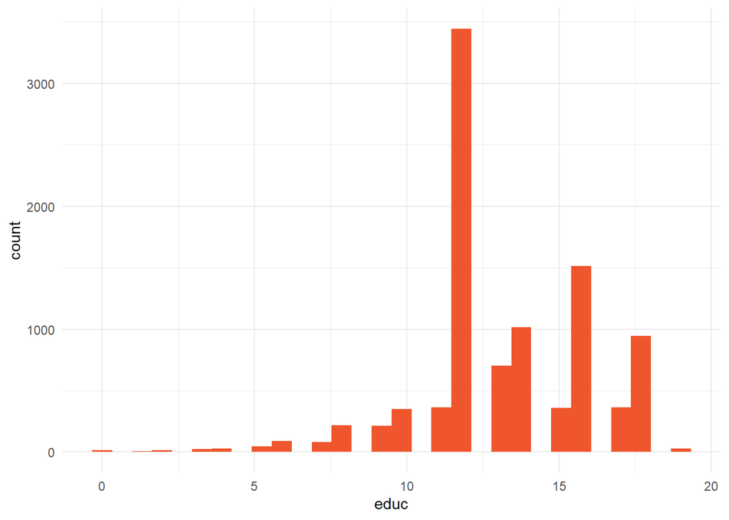

```r
ggplot(df) +
 aes(x = educ) +
 geom_histogram(bins = 30L, fill = "#EF562D") +
 theme_minimal()
```

Grafico referente a porcentagem de homens que abusa ou não de álcool.

[figure not shown]

```r
fatia <- df$abuse
fatias <- table(fatia)
rotulos <- c("Abusa", "Não abusa")
percent <- round(fatias/sum(fatias)*100,digits=1)
rotulos <- paste(rotulos, percent)
rotulos <- paste(rotulos, "%", sep="")
pie(fatias,labels = rotulos, col=c("lightseagreen","indianred2"))
```

### Conclusões

Através dessa análise pude chegar a conclusão que da amostra total de 9822 homens, menos de 10% abusam do álcool, também pude chegar na conclusão de que a idade não é um fator determinante para abusar ou não, uma vez que podemos observar que a amostra são semelhantes, assim como o tempo na escola. Acredito que com uma amostra mais densa e com mais distinção (um numero maior de pessoas que abusam) seria possível gerar uma analisa mais detalhada.